# Reproducible Research: Week 2 Assignment

Author: Mustafa Khokhawala Date: 10-Jul-2016

### General settings

```r
echo = TRUE  # Code visible
# options(scipen = 1)  # Disable scientific notations
```

### Loading pre-requisite libraries/packages

```r
library(dplyr)
library(lubridate)
```

```r
library(ggplot2)
```

### Loading the data

```r
#Set working directory
setwd("~/coursera/RR/week2")

#Load the CSV file
activityData <- read.csv("activity.csv", header=TRUE, colClasses = c("numeric", "character", "integer"))
```

### Cleaning the data

```r
activityData$date <- ymd(activityData$date)

#Check the data with str
str(activityData)
```

```
## 'data.frame':    17568 obs. of  3 variables:
##  $ steps   : num  NA NA NA NA NA NA NA NA NA NA ...
##  $ date    : Date, format: "2012-10-01" "2012-10-01" ...
##  $ interval: int  0 5 10 15 20 25 30 35 40 45 ...
```

### What is mean total number of steps taken per day?

Calculate and report the total steps taken per day and plot a histogram

```r
#Calculate the steps taken daily
stepsDaily <- activityData %>%
  filter(!is.na(steps)) %>%
  group_by(date) %>%
  summarize(steps = sum(steps)) %>%
  print
```

```
## Source: local data frame [53 x 2]
##
##          date steps
##        (date) (dbl)
## 1  2012-10-02   126
## 2  2012-10-03 11352
## 3  2012-10-04 12116
## 4  2012-10-05 13294
## 5  2012-10-06 15420
## 6  2012-10-07 11015
## 7  2012-10-09 12811
## 8  2012-10-10  9900
## 9  2012-10-11 10304
## 10 2012-10-12 17382
## ..        ...   ...
```

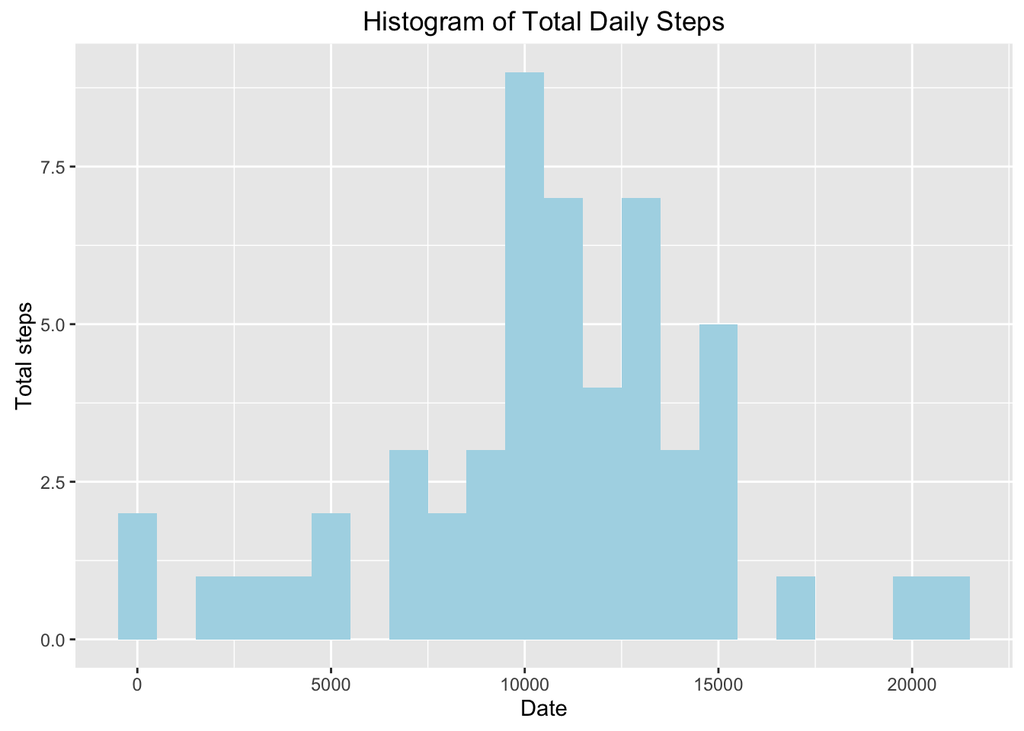

```r
#Plot a histogram
ggplot(stepsDaily, aes(x = steps)) +
  geom_histogram(fill = "lightblue", binwidth = 1000) + labs(title = "Histogram of Total Daily Steps", x = "Date", y = "Total steps")
```

Mean total number of steps taken daily….

```r
totalSteps <- aggregate(stepsDaily$steps, list(Date = stepsDaily$date), FUN = "sum")$x
mean(totalSteps)
```

```
## [1] 10766.19
```

Median total of steps taken daily….

```r
median(totalSteps)
```

```
## [1] 10765
```

### What is the average daily activity pattern?

Calculate the average number of steps taken in each 5-minute interval per day and group by interval

```r
interval <- activityData %>%
  filter(!is.na(steps)) %>%
  group_by(interval) %>%
  summarize(steps = mean(steps))
```

Use ggplot for making the time series of 5-minute intervals

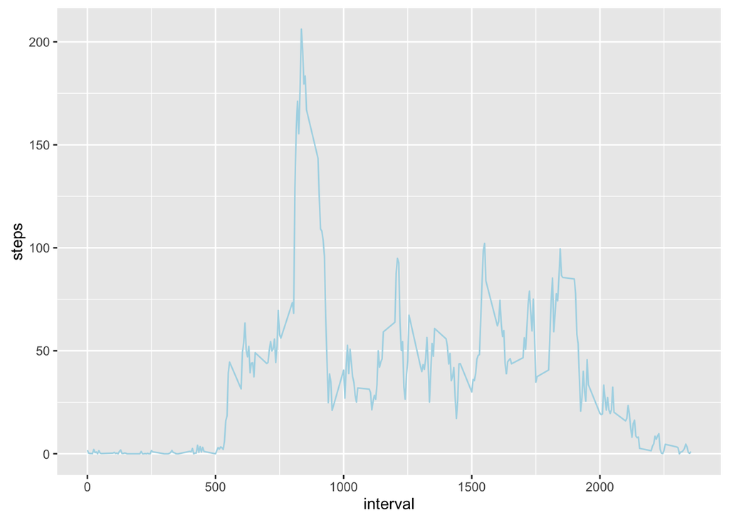

```r
ggplot(interval, aes(x=interval, y=steps)) + geom_line(color = "lightblue")
```

Use which.max() to find out the maximum steps, on average, across all the days:

```r
interval[which.max(interval$steps),]
```

```
## Source: local data frame [1 x 2]
##
##   interval    steps
##      (int)    (dbl)
## 1      835 206.1698
```

### Imputing missing values

The total number of rows with NAs:

```r
sum(is.na(activityData))
```

```
## [1] 2304
```

Fll in a missing NA with the average number of steps in the same 5-min interval. Create a new dataset as the original and use tapply for filling in the missing values with the average number of steps per 5-minute interval:

```r
 activityDataFull <- activityData
nas <- is.na(activityDataFull$steps)
avg_interval <- tapply(activityDataFull$steps, activityDataFull$interval, mean, na.rm=TRUE, simplify=TRUE)
activityDataFull$steps[nas] <- avg_interval[as.character(activityDataFull$interval[nas])]
```

Ensure that there are no missing values…

```r
sum(is.na(activityDataFull$steps))
```

```
## [1] 0
```

```r
stepsFull <- activityDataFull %>%
  filter(!is.na(steps)) %>%
  group_by(date) %>%
  summarize(steps = sum(steps)) %>%
  print
```

```
## Source: local data frame [61 x 2]
##
##          date    steps
##        (date)    (dbl)
## 1  2012-10-01 10766.19
## 2  2012-10-02   126.00
## 3  2012-10-03 11352.00
## 4  2012-10-04 12116.00
## 5  2012-10-05 13294.00
## 6  2012-10-06 15420.00
## 7  2012-10-07 11015.00
## 8  2012-10-08 10766.19
## 9  2012-10-09 12811.00
## 10 2012-10-10  9900.00
## ..        ...      ...
```

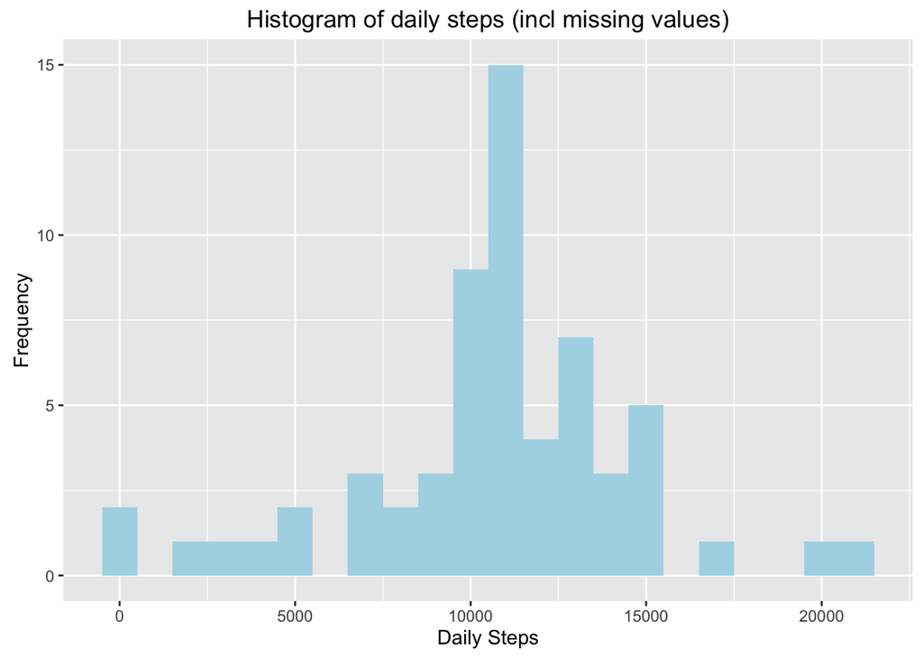

```r
ggplot(stepsFull, aes(x = steps)) +
  geom_histogram(fill = "lightblue", binwidth = 1000) +
  labs(title = "Histogram of daily steps (incl missing values)", x = "Daily Steps", y = "Frequency")
```

Calculate the mean and median steps with the filled in values:

```r
meanFull <- mean(stepsFull$steps, na.rm = TRUE)
medianFull <- median(stepsFull$steps, na.rm = TRUE)
meanFull
```

```
## [1] 10766.19
```

```r
medianFull
```

```
## [1] 10766.19
```

### Are there differences in activity patterns between weekdays and weekends?

Create a new factor variable in the dataset with two levels – “weekday” and “weekend” indicating whether a given date is a weekday or weekend day. Make a panel plot containing a time series plot (i.e. 𝚝𝚢𝚙𝚎 = “𝚕”) of the 5-minute interval (x-axis) and the average number of steps taken, averaged across all weekday days or weekend days (y-axis).

Use dplyr and mutate to create a new column, weektype, and apply whether the day is weekend or weekday…

```r
activityDataFull <- mutate(activityDataFull, weektype = ifelse(weekdays(activityDataFull$date) == "Saturday" | weekdays(activityDataFull$date) == "Sunday", "weekend", "weekday"))
activityDataFull$weektype <- as.factor(activityDataFull$weektype)
head(activityDataFull)
```

```
##       steps       date interval weektype
## 1 1.7169811 2012-10-01        0  weekday
## 2 0.3396226 2012-10-01        5  weekday
## 3 0.1320755 2012-10-01       10  weekday
## 4 0.1509434 2012-10-01       15  weekday
## 5 0.0754717 2012-10-01       20  weekday
## 6 2.0943396 2012-10-01       25  weekday
```

Calculate the average steps in the 5-minute interval and use ggplot for making the time series of the 5-minute interval for weekday and weekend, and compare the average steps:

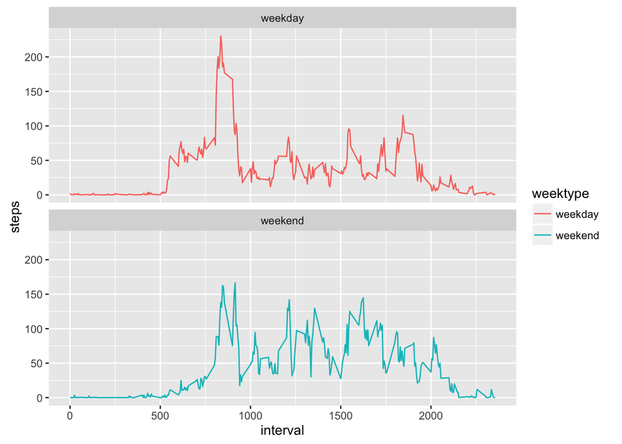

```r
intervalFull <- activityDataFull %>%
  group_by(interval, weektype) %>%
  summarise(steps = mean(steps))

panelplot <- ggplot(intervalFull, aes(x=interval, y=steps, color = weektype)) +
  geom_line() +
  facet_wrap(~weektype, ncol = 1, nrow=2)
print(panelplot)
```

From the plot it appears that the subjects are the most active in the earlier part of the weekday compared to the weekend.